# Intro to Data Analysis with R: Exercise 3 Solutions

UCI Data Science Initiative

## Introduction

In this set of Exercises, we will explore linear regression, variable selection, model diagnostics and prediction.

### Part A

**A.1** Open a new R script and save it in the directory you created in Part A.1 of Exercise 1. Then, load the Auto MPG data set with the additional variable `diesel` using the `load()` function and file path from the end of Exercise 1.

```r
load("../data/auto_mpg_v2.Rda")
```

**A.2** Regress MPG on horsepower and look at the model results with the `summary()` function. Interpret the meaning of the coefficient of horsepower.

```r
linFit <- lm(mpg ~ hp, data=auto)
summary(linFit)
```

```
##
## Call:
## lm(formula = mpg ~ hp, data = auto)
##
## Residuals:
##      Min       1Q   Median       3Q      Max
## -13.5710  -3.2592  -0.3435   2.7630  16.9240
##
## Coefficients:
##              Estimate Std. Error t value Pr(>|t|)
## (Intercept) 39.935861   0.717499   55.66   <2e-16 ***
## hp          -0.157845   0.006446  -24.49   <2e-16 ***
## ---
## Signif. codes:  0 '***' 0.001 '**' 0.01 '*' 0.05 '.' 0.1 ' ' 1
##
## Residual standard error: 4.906 on 390 degrees of freedom
##   (14 observations deleted due to missingness)
## Multiple R-squared:  0.6059, Adjusted R-squared:  0.6049
## F-statistic: 599.7 on 1 and 390 DF,  p-value: < 2.2e-16
```

*We estimate that, on average, fuel economy decreases by 0.16 mpg for every one unit increase in horsepower.*

**A.3** Plot the model diagnostics. Do you think this model fits the data adequately? Why or why not?

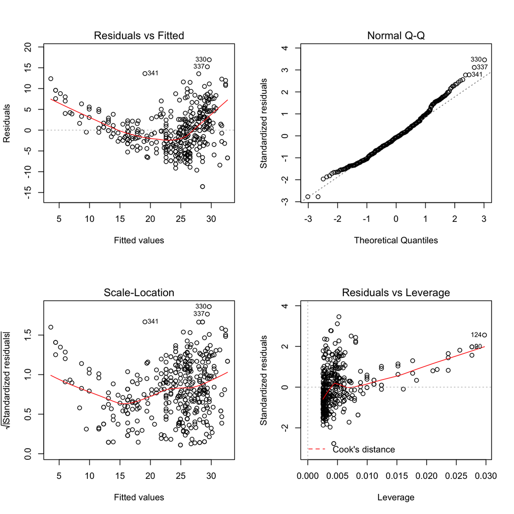

```r
par(mfrow=c(2,2))
plot(linFit)
```

### Part B

**B.1** Add in a quadratic term for horsepower and look at the model fit results. HINT: Use the indicator function `I()` along with `update()`.

```r
quadFit <- update(linFit, ~ . + I(hp^2), data=auto)
summary(quadFit)
```

```
##
## Call:
## lm(formula = mpg ~ hp + I(hp^2), data = auto)
##
## Residuals:
##      Min       1Q   Median       3Q      Max
## -14.7135  -2.5943  -0.0859   2.2868  15.8961
##
## Coefficients:
##               Estimate Std. Error t value Pr(>|t|)
## (Intercept) 56.9000997  1.8004268   31.60   <2e-16 ***
## hp          -0.4661896  0.0311246  -14.98   <2e-16 ***
## I(hp^2)      0.0012305  0.0001221   10.08   <2e-16 ***
## ---
## Signif. codes:  0 '***' 0.001 '**' 0.01 '*' 0.05 '.' 0.1 ' ' 1
##
## Residual standard error: 4.374 on 389 degrees of freedom
##   (14 observations deleted due to missingness)
## Multiple R-squared:  0.6876, Adjusted R-squared:  0.686
## F-statistic:   428 on 2 and 389 DF,  p-value: < 2.2e-16
```

**B.2** Plot the model diagnostics. Do you think this model fits the data adequately? Why or why not?

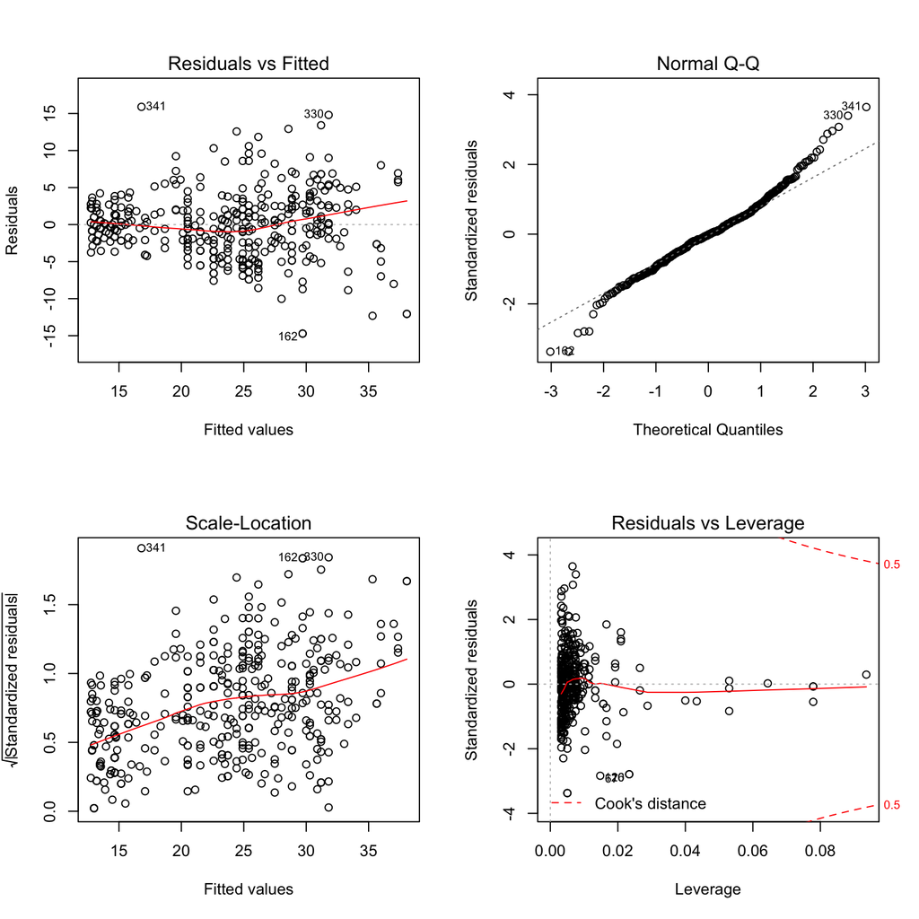

```r
par(mfrow=c(2,2))
plot(quadFit)
```

**B.3** Compare the model from Part A to the model you just fit using an F-test. What model do you conclude fits the data better?

```r
anova(linFit, quadFit)
```

```
## Analysis of Variance Table
##
## Model 1: mpg ~ hp
## Model 2: mpg ~ hp + I(hp^2)
##   Res.Df    RSS Df Sum of Sq      F    Pr(>F)
## 1    390 9385.9
## 2    389 7442.0  1    1943.9 101.61 < 2.2e-16 ***
## ---
## Signif. codes:  0 '***' 0.001 '**' 0.01 '*' 0.05 '.' 0.1 ' ' 1
```

*We reject the null hypothesis and conclude that the full model with horsepower squared fits better than the reduced model.*

**B.4** Make a scatterplot of mpg versus horsepower. Add the estimated regression line from Part A using the `abline()` function and color it red. Add in the estimated regression line from Part B and color it blue. HINT: You will need to use the `predict()` and `curve()` functions.

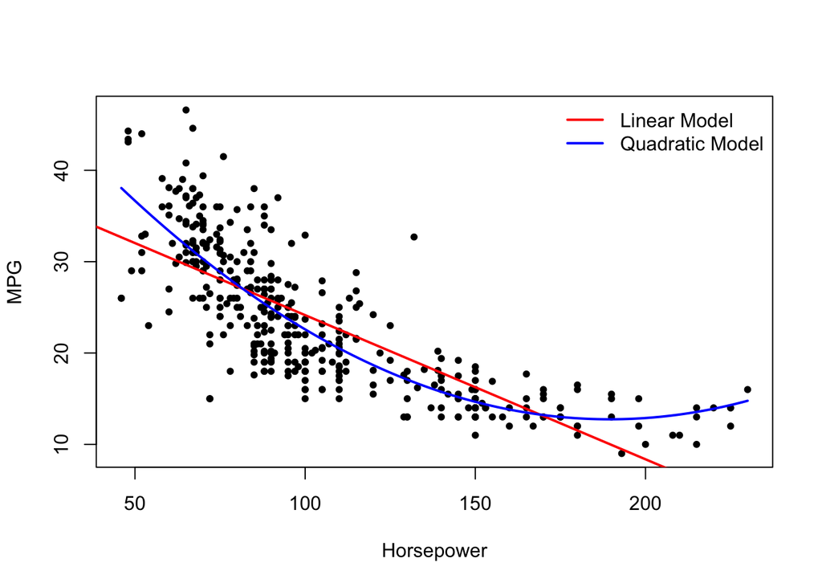

```r
plot(auto$hp, auto$mpg, pch=20, xlab="Horsepower", ylab="MPG")
abline(reg = linFit, col="red", lwd=2)
curve(predict(quadFit, data.frame(hp=x)), add=TRUE, col="blue", lwd=2)
legend("topright", legend=c("Linear Model", "Quadratic Model"), col=c("red","blue"), lty=1, lwd=2, bty="n")
```

### Part C

**C.1** Using what you’ve learned so far, fit the best possible linear model you can to predict MPG. Answers will vary. HINT: You can use automatic variable selection methods, or do so manually and compare models via adjusted $R^2$ and F-tests.

```r
modelC1 <- lm(mpg ~ weight + model.yr, data=auto)
summary(modelC1)
```

```
##
## Call:
## lm(formula = mpg ~ weight + model.yr, data = auto)
##
## Residuals:
##     Min      1Q  Median      3Q     Max
## -8.8777 -2.3140 -0.1211  2.0591 14.3330
##
## Coefficients:
##               Estimate Std. Error t value Pr(>|t|)
## (Intercept) -1.420e+01  3.968e+00  -3.578 0.000389 ***
## weight      -6.664e-03  2.139e-04 -31.161  < 2e-16 ***
## model.yr     7.566e-01  4.898e-02  15.447  < 2e-16 ***
## ---
## Signif. codes:  0 '***' 0.001 '**' 0.01 '*' 0.05 '.' 0.1 ' ' 1
##
## Residual standard error: 3.435 on 395 degrees of freedom
##   (8 observations deleted due to missingness)
## Multiple R-squared:  0.8079, Adjusted R-squared:  0.8069
## F-statistic: 830.4 on 2 and 395 DF,  p-value: < 2.2e-16
```

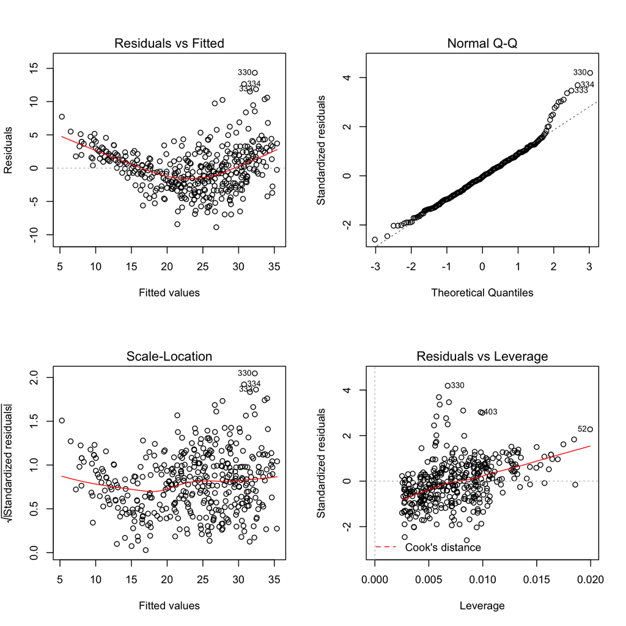

```r
par(mfrow=c(2,2)); plot(modelC1)
```

```r
auto[c(330, 334, 333), ]  # look at potential outliers... top 3 mpg values
```

```
##      mpg cyl disp hp weight  acc model.yr origin                 name
## 330 46.6   4   86 65   2110 17.9       80      3            mazda glc
## 334 43.4   4   90 48   2335 23.7       80      2   vw dasher (diesel)
## 333 44.3   4   90 48   2085 21.7       80      2 vw rabbit c (diesel)
##     diesel
## 330      0
## 334      1
## 333      1
```

```r
auto[52, c("mpg", "weight", "model.yr")]  # look at leverage point... heaviest vehicle
```

```
##    mpg weight model.yr
## 52  13   5140       71
```

```r
modelC2 <- lm(mpg ~ weight + I(weight^2) + model.yr, data=auto)
summary(modelC2)
```

```
##
## Call:
## lm(formula = mpg ~ weight + I(weight^2) + model.yr, data = auto)
##
## Residuals:
##     Min      1Q  Median      3Q     Max
## -9.4771 -1.7156 -0.1581  1.5327 13.1433
##
## Coefficients:
##               Estimate Std. Error t value Pr(>|t|)
## (Intercept)  2.397e+00  3.823e+00   0.627    0.531
## weight      -2.182e-02  1.426e-03 -15.296   <2e-16 ***
## I(weight^2)  2.388e-06  2.228e-07  10.718   <2e-16 ***
## model.yr     8.308e-01  4.370e-02  19.010   <2e-16 ***
## ---
## Signif. codes:  0 '***' 0.001 '**' 0.01 '*' 0.05 '.' 0.1 ' ' 1
##
## Residual standard error: 3.026 on 394 degrees of freedom
##   (8 observations deleted due to missingness)
## Multiple R-squared:  0.8512, Adjusted R-squared:  0.8501
## F-statistic: 751.5 on 3 and 394 DF,  p-value: < 2.2e-16
```

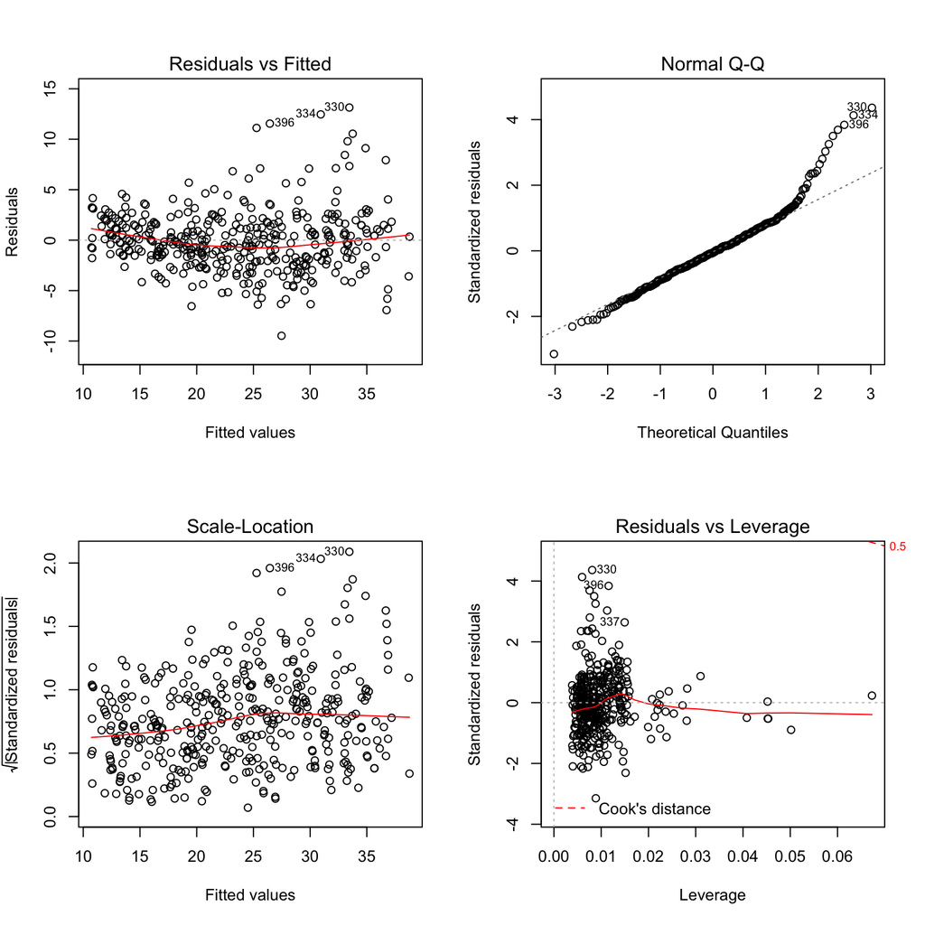

```r
par(mfrow=c(2,2)); plot(modelC2)
```

```r
auto[c(330, 334, 396), c("mpg", "weight", "model.yr")]  # look at potential outliers... top 3 mpg values
```

```
##      mpg weight model.yr
## 330 46.6   2110       80
## 334 43.4   2335       80
## 396 38.0   3015       82
```

```r
anova(modelC1, modelC2)
```

```
## Analysis of Variance Table
##
## Model 1: mpg ~ weight + model.yr
## Model 2: mpg ~ weight + I(weight^2) + model.yr
##   Res.Df    RSS Df Sum of Sq      F    Pr(>F)
## 1    395 4659.8
## 2    394 3607.8  1      1052 114.88 < 2.2e-16 ***
## ---
## Signif. codes:  0 '***' 0.001 '**' 0.01 '*' 0.05 '.' 0.1 ' ' 1
```

```r
finalModel <- lm(mpg ~ weight + I(weight^2) + model.yr + diesel, data=auto)
summary(finalModel)
```

```
##
## Call:
## lm(formula = mpg ~ weight + I(weight^2) + model.yr + diesel,
##     data = auto)
##
## Residuals:
##     Min      1Q  Median      3Q     Max
## -9.4833 -1.6161 -0.0464  1.6154 13.5027
##
## Coefficients:
##               Estimate Std. Error t value Pr(>|t|)
## (Intercept)  6.708e+00  3.503e+00   1.915   0.0562 .
## weight      -2.215e-02  1.296e-03 -17.098   <2e-16 ***
## I(weight^2)  2.440e-06  2.024e-07  12.058   <2e-16 ***
## model.yr     7.784e-01  4.009e-02  19.416   <2e-16 ***
## diesel1      9.776e+00  1.061e+00   9.214   <2e-16 ***
## ---
## Signif. codes:  0 '***' 0.001 '**' 0.01 '*' 0.05 '.' 0.1 ' ' 1
##
## Residual standard error: 2.748 on 393 degrees of freedom
##   (8 observations deleted due to missingness)
## Multiple R-squared:  0.8777, Adjusted R-squared:  0.8764
## F-statistic: 704.9 on 4 and 393 DF,  p-value: < 2.2e-16
```

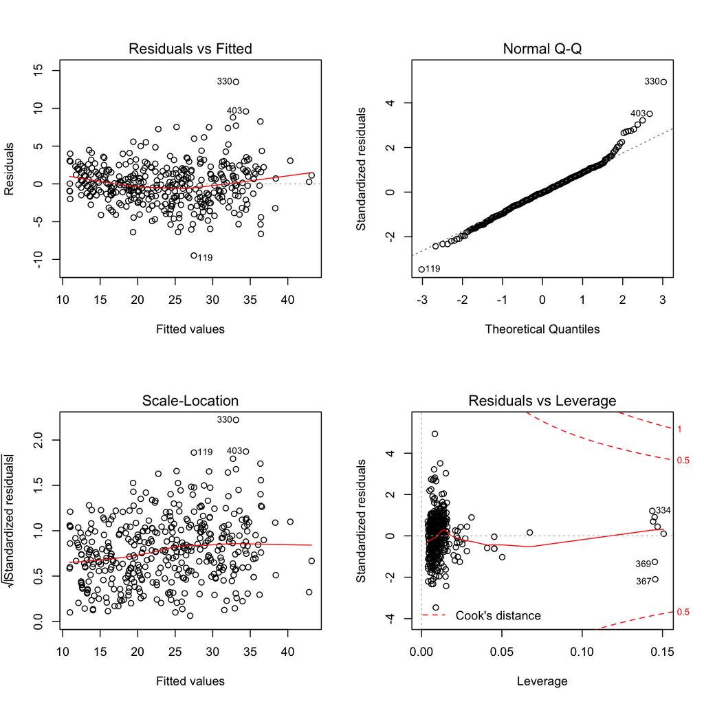

```r
par(mfrow=c(2,2)); plot(finalModel)
```

```r
auto[c(330, 403, 119), ]  # look at potential outliers...
```

```
##      mpg cyl disp hp weight  acc model.yr origin      name diesel
## 330 46.6   4   86 65   2110 17.9       80      3 mazda glc      0
## 403 44.0   4   97 52   2130 24.6       82      2 vw pickup      0
## 119 18.0   3   70 90   2124 13.5       73      3 maxda rx3      0
```

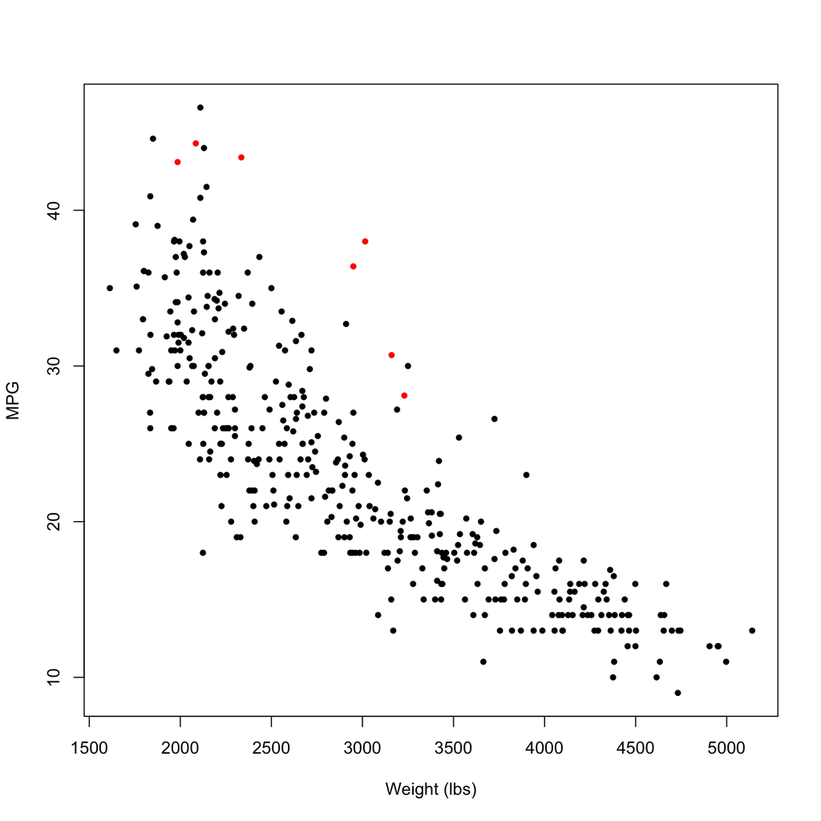

```r
par(mfrow=c(1,1)); plot(auto$weight, auto$mpg, pch=20, xlab="Weight (lbs)", ylab="MPG", col=auto$diesel)
```

```r
anova(modelC2, finalModel)
```

```
## Analysis of Variance Table
##
## Model 1: mpg ~ weight + I(weight^2) + model.yr
## Model 2: mpg ~ weight + I(weight^2) + model.yr + diesel
##   Res.Df    RSS Df Sum of Sq      F    Pr(>F)
## 1    394 3607.8
## 2    393 2966.9  1    640.95 84.902 < 2.2e-16 ***
## ---
## Signif. codes:  0 '***' 0.001 '**' 0.01 '*' 0.05 '.' 0.1 ' ' 1
```

**C.2** Using the model you just fit, predict the fuel economy of the 8 vehicles with missing mpg values.

```r
missing.mpg <- auto[is.na(auto$mpg), ]
cbind(missing.mpg, fit=predict(finalModel, newdata = missing.mpg))
```

```
##     mpg cyl disp  hp weight  acc model.yr origin
## 11   NA   4  133 115   3090 17.5       70      2
## 12   NA   8  350 165   4142 11.5       70      1
## 13   NA   8  351 153   4034 11.0       70      1
## 14   NA   8  383 175   4166 10.5       70      1
## 15   NA   8  360 175   3850 11.0       70      1
## 18   NA   8  302 140   3353  8.0       70      1
## 40   NA   4   97  48   1978 20.0       71      2
## 368  NA   4  121 110   2800 15.4       81      2
##                                 name diesel      fit
## 11              citroen ds-21 pallas      0 16.03857
## 12  chevrolet chevelle concours (sw)      0 11.29794
## 13                  ford torino (sw)      0 11.53585
## 14           plymouth satellite (sw)      0 11.25280
## 15                amc rebel sst (sw)      0 12.07229
## 18             ford mustang boss 302      0 14.34709
## 40       volkswagen super beetle 117      0 27.69954
## 368                        saab 900s      0 26.85690
```

### Part D

Write a function that performs linear contrasts. E.g., takes in the fitted linear regression object and a vector containing the difference in two predictor vectors and ourputs a point estimate and 95% confidence interval. Specifically, do this comparing (1) two similar vehicles that differ by 10 model years, and (2) two similar vehicles that differ by 500 pounds. NOTE: You may not have included these variables in your final model. If you didn’t, chose two other variables. HINT: This problem is difficult! You will need to get the covariance matrix on the coefficients with `vcov()` and perform some matrix multiplications using the `%*%` operator. Ask for help if you make it this far!

```r
linContr <- function(model, contr){
  beta.hat <- model$coef
  cov.beta <- vcov(model)
  est <- contr %*% beta.hat
  se.est <- sqrt(contr %*% cov.beta %*% t(contr))
  ci95.lo <- est - qnorm(0.975)*se.est
  ci95.hi <- est + qnorm(0.975)*se.est
  out <- data.frame(est, se.est, ci95.lo, ci95.hi)
  round(out, 3)
}

linContr(finalModel, matrix(c(0, 0, 0, 10, 0), nrow=1, ncol=5))  # 10 yr diff
```

```
##     est se.est ci95.lo ci95.hi
## 1 7.784  0.401   6.998   8.569
```

```r
linContr(finalModel, matrix(c(0, -500, -500^2, 0, 0), nrow=1, ncol=5))  # 500 lb diff
```

```
##      est se.est ci95.lo ci95.hi
## 1 10.466  0.598   9.295  11.638
```